# Lesson 3

### What to Do First?

**Notes:** Verificar a pasta que se encontra, caso necessário trocar a pasta e listar os arquivos.

```r
getwd()
```

```
## [1] "/home/rstudio/EDA_Course_Materials/lesson3"
```

```r
list.files()
```

```
## [1] "lesson3_student.html" "lesson3_student.rmd"  "pseudo_facebook.tsv"
```

### Pseudo-Facebook User Data

**Notes:** Carregar os dados em uma variável.

```r
df <- read.delim('pseudo_facebook.tsv')
head(df)
```

```
##    userid age dob_day dob_year dob_month gender tenure friend_count
## 1 2094382  14      19     1999        11   male    266            0
## 2 1192601  14       2     1999        11 female      6            0
## 3 2083884  14      16     1999        11   male     13            0
## 4 1203168  14      25     1999        12 female     93            0
## 5 1733186  14       4     1999        12   male     82            0
## 6 1524765  14       1     1999        12   male     15            0
##   friendships_initiated likes likes_received mobile_likes
## 1                     0     0              0            0
## 2                     0     0              0            0
## 3                     0     0              0            0
## 4                     0     0              0            0
## 5                     0     0              0            0
## 6                     0     0              0            0
##   mobile_likes_received www_likes www_likes_received
## 1                     0         0                  0
## 2                     0         0                  0
## 3                     0         0                  0
## 4                     0         0                  0
## 5                     0         0                  0
## 6                     0         0                  0
```

### Histogram of Users’ Birthdays

Notes:

```r
install.packages('ggplot2')
library(ggplot2)
```

### Moira’s Investigation

Notes:

### Estimating Your Audience Size

Notes:

#### Think about a time when you posted a specific message or shared a photo on Facebook. What was it?

**Response:** A foto de um lanche artesanal que fizemos entre amigos.

#### How many of your friends do you think saw that post?

**Response:** 10

#### Think about what percent of your friends on Facebook see any posts or comments that you make in a month. What percent do you think that is?

**Response:** 60%

### Perceived Audience Size

Notes:

### Faceting

Notes:

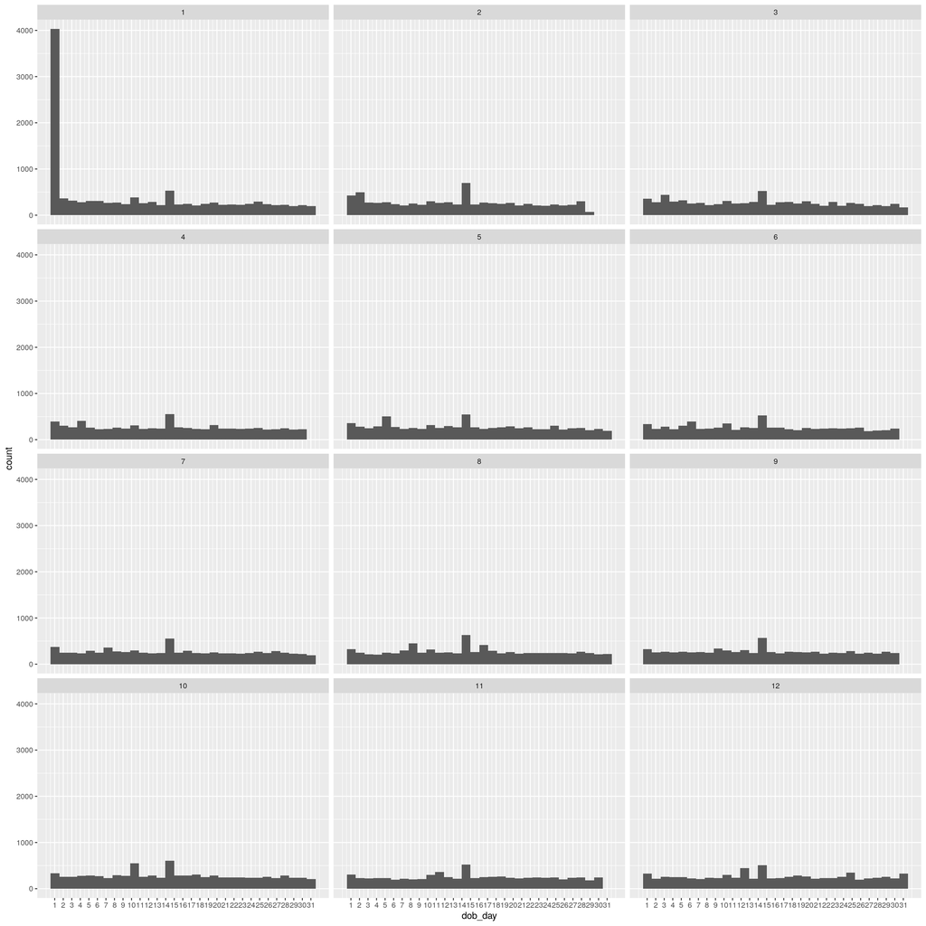

```r
ggplot(data=df, aes(x=dob_day)) +
  geom_histogram() +
  scale_x_continuous(breaks=1:31) +
  facet_wrap(~dob_month, ncol=3)
```

#### Let’s take another look at our plot. What stands out to you here?

Response:

### Be Skeptical - Outliers and Anomalies

Notes:

### Friend Count

Notes:

#### What code would you enter to create a histogram of friend counts?

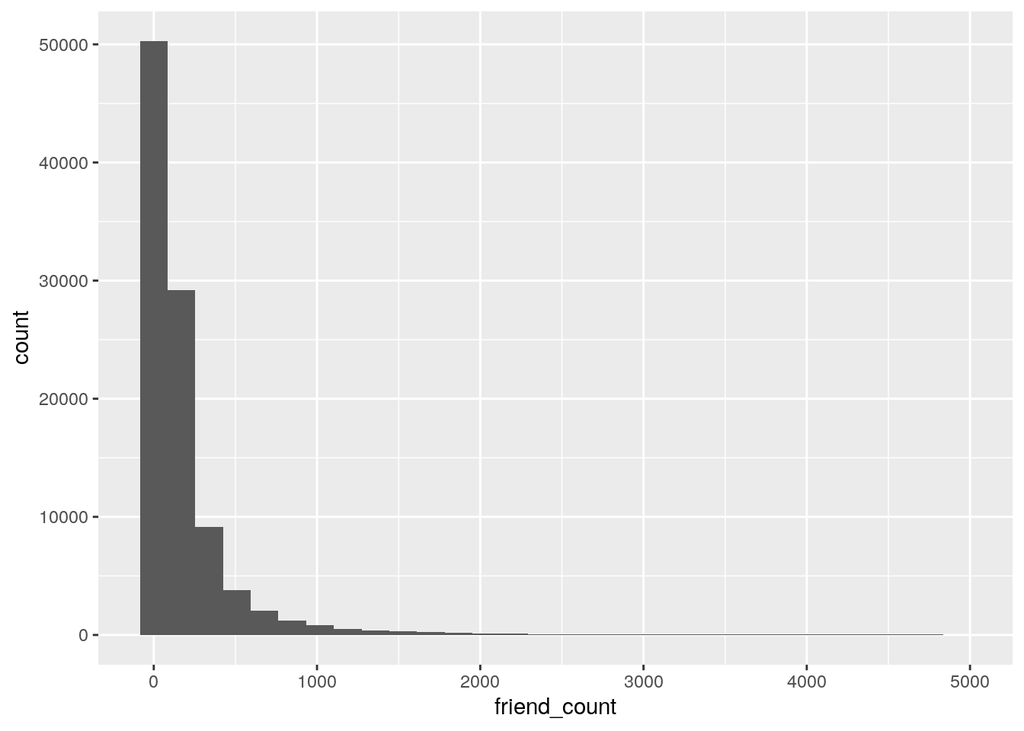

```r
# qplot(data=df, x=friend_count)
ggplot(aes(x=friend_count), data=df) +
  geom_histogram()
```

### Limiting the Axes

Notes:

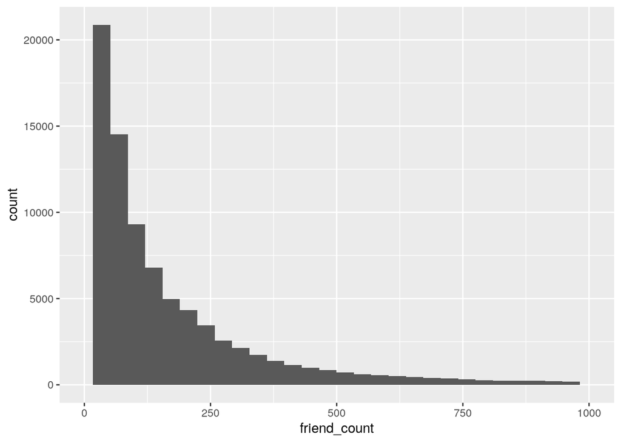

```r
# qplot(x = friend_count, data = df, xlim = c(1,1000)) + labs(y = 'count')
ggplot(aes(x = friend_count), data = df) +
  geom_histogram() +
  scale_x_continuous(limits = c(1,1000))
```

### Exploring with Bin Width

**Notes:** A grande maioria dos valores escolhidos eram entre 20, 50 e 100

### Adjusting the Bin Width

Notes:

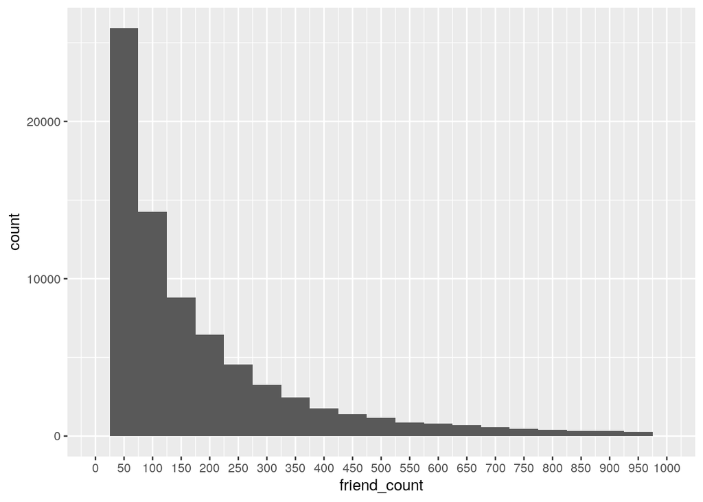

```r
ggplot(aes(x=friend_count), data=df) +
  geom_histogram(binwidth=50) +
  scale_x_continuous(limits=c(1,1000), breaks=seq(0,1000,50))
```

### Faceting Friend Count

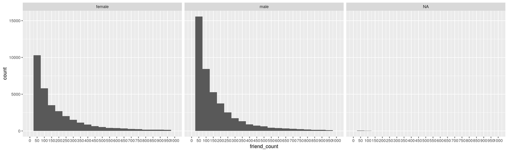

```r
# What code would you add to create a facet the histogram by gender?
# Add it to the code below.
# qplot(x = friend_count, data = df, binwidth = 50) +
#   scale_x_continuous(limits = c(0, 1000),
#                      breaks = seq(0, 1000, 50)) +
#   facet_grid(~gender)
ggplot(aes(x = friend_count), data = df) +
  geom_histogram(binwidth = 50) +
  scale_x_continuous(limits = c(1,1000),
                     breaks = seq(0,1000,50)) +
  facet_grid(~gender)
```

### Omitting NA Values

Notes:

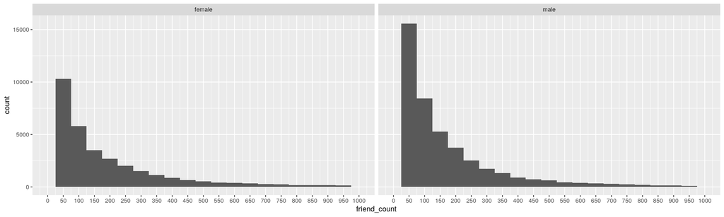

```r
ggplot(aes(x = friend_count), data = subset(df, !is.na(gender))) +
  geom_histogram(binwidth = 50) +
  scale_x_continuous(limits = c(1, 1000),
                     breaks = seq(0, 1000, 50)) +
  facet_grid(~gender)
```

### Statistics ‘by’ Gender

Notes:

```r
table(df$gender)
```

```
##
## female   male
##  40254  58574
```

```r
by(df$friend_count, df$gender, summary)
```

```
## df$gender: female
##    Min. 1st Qu.  Median    Mean 3rd Qu.    Max.
##       0      37      96     242     244    4923
## --------------------------------------------------------
## df$gender: male
##    Min. 1st Qu.  Median    Mean 3rd Qu.    Max.
##       0      27      74     165     182    4917
```

```r
fq <- by(df$friend_count, df$gender, summary)
round(fq$female[3]) -  round(fq$male[3])
```

```
## Median
##     22
```

#### Who on average has more friends: men or women?

**Response:** Mulheres em média tem mais amigos.

#### What’s the difference between the median friend count for women and men?

**Response:** 22

#### Why would the median be a better measure than the mean?

**Response:** A mediana é um valor mais robusto, como os grupos tem quantidades diferentes, uma contagem maior de usuários pode modificar a média de amigos.

### Tenure

Notes:

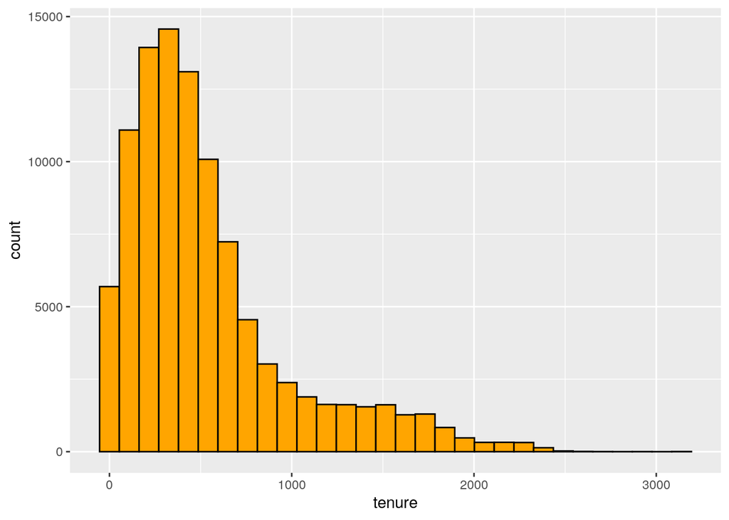

```r
ggplot(aes(x = tenure), data = df) +
  geom_histogram(color = 'black', fill = 'orange')
```

#### How would you create a histogram of tenure by year?

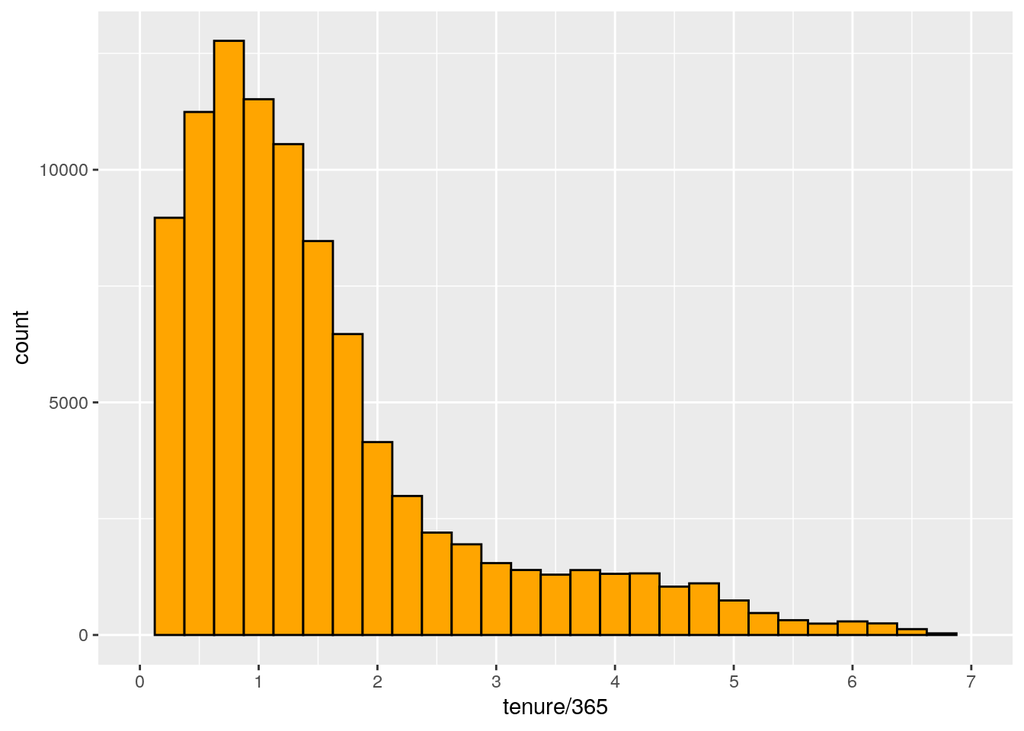

```r
ggplot(aes(x = tenure/365), data = df) +
  geom_histogram(binwidth = .25, color = 'black', fill = 'orange') +
  scale_x_continuous(limits = c(0, 7),
                     breaks = seq(0, 7, 1))
```

### Labeling Plots

Notes:

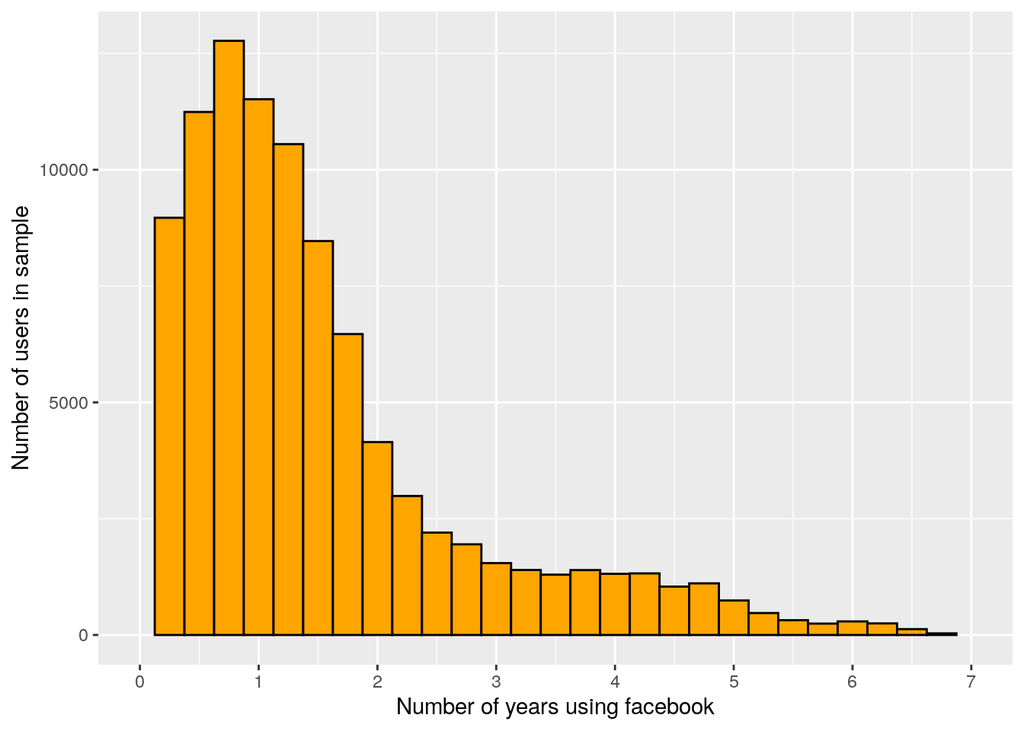

```r
ggplot(aes(x = tenure/365), data = df) +
  geom_histogram(binwidth = .25, color = 'black', fill = 'orange') +
  scale_x_continuous(limits = c(0, 7),
                     breaks = seq(0, 7, 1)) +
  ylab('Number of users in sample') +
  xlab('Number of years using facebook')
```

### User Ages

Notes:

```r
summary(df$age)
```

```
##    Min. 1st Qu.  Median    Mean 3rd Qu.    Max.
##   13.00   20.00   28.00   37.28   50.00  113.00
```

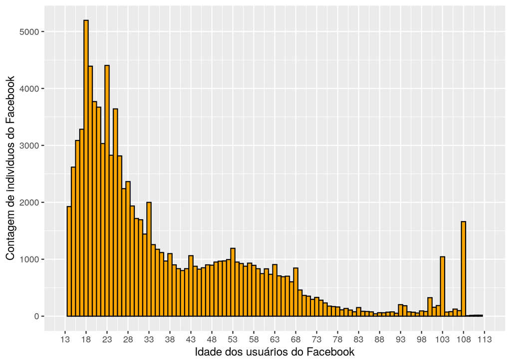

```r
ggplot(aes(x = age), data = df) +
  geom_histogram(binwidth = 1, color = 'black', fill = 'orange') +
  scale_x_continuous(limits = c(13, 113),
                     breaks = seq(13, 113, 5)) +
  xlab('Idade dos usuários do Facebook') +
  ylab('Contagem de individuos do Facebook')
```

#### What do you notice?

**Response:** Não existem contagem de pessoas a baixo dos 13 anos e existe contagens altas de pessoas com idades avançadas o que informa outliers além de outros picos.

### The Spread of Memes

Notes:

### Lada’s Money Bag Meme

Notes:

### Transforming Data

Notes:

```r
install.packages("gridExtra")
library(gridExtra)
```

```r
p1 <- ggplot(aes(x = friend_count), data = df) +
  geom_histogram(binwidth = 30, color = 'black', fill = 'blue') +
  scale_x_continuous(limits = c(1, 1000),
                     breaks = seq(0, 1000, 100)) +
  ylab('Count facebook users') +
  xlab('Friends normal count')

# Log_10
df$log_fc <- log10(df$friend_count + 1)
summary(df$log_fc)
```

```
##    Min. 1st Qu.  Median    Mean 3rd Qu.    Max.
##   0.000   1.505   1.919   1.868   2.316   3.692
```

```r
p2 <- ggplot(aes(x = log_fc), data = df) +
  geom_histogram(binwidth = .25, color = 'black', fill = 'green') +
  scale_x_continuous(limits = c(0, 4),
                     breaks = seq(0, 4, 0.5)) +
  ylab('') +
  xlab('Friends log_10 count')

df <- subset(df, select = -log_fc)

# SQRT
df$sqr_fc <- sqrt(df$friend_count)
summary(df$sqr_fc)
```

```
##    Min. 1st Qu.  Median    Mean 3rd Qu.    Max.
##   0.000   5.568   9.055  11.088  14.353  70.164
```

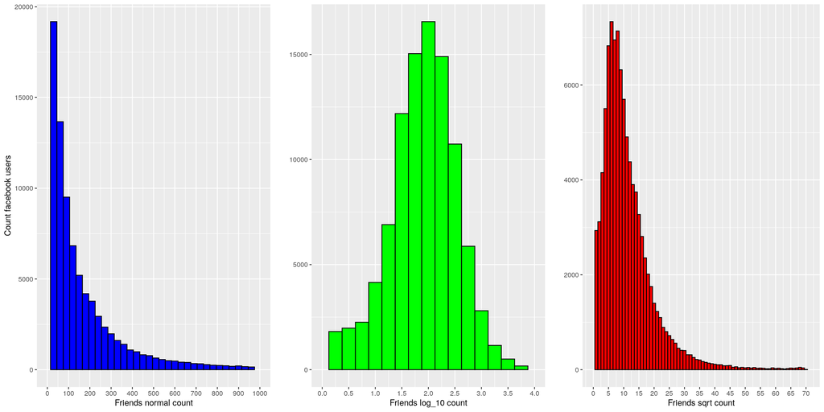

```r
p3 <- ggplot(aes(x = sqr_fc), data = df) +
  geom_histogram(binwidth = 1, color = 'black', fill = 'red') +
  scale_x_continuous(limits = c(0, 71),
                     breaks = seq(0, 71, 5)) +
  ylab('') +
  xlab('Friends sqrt count')

df <- subset(df, select = -sqr_fc)

grid.arrange(p1, p2, p3, ncol = 3)
```

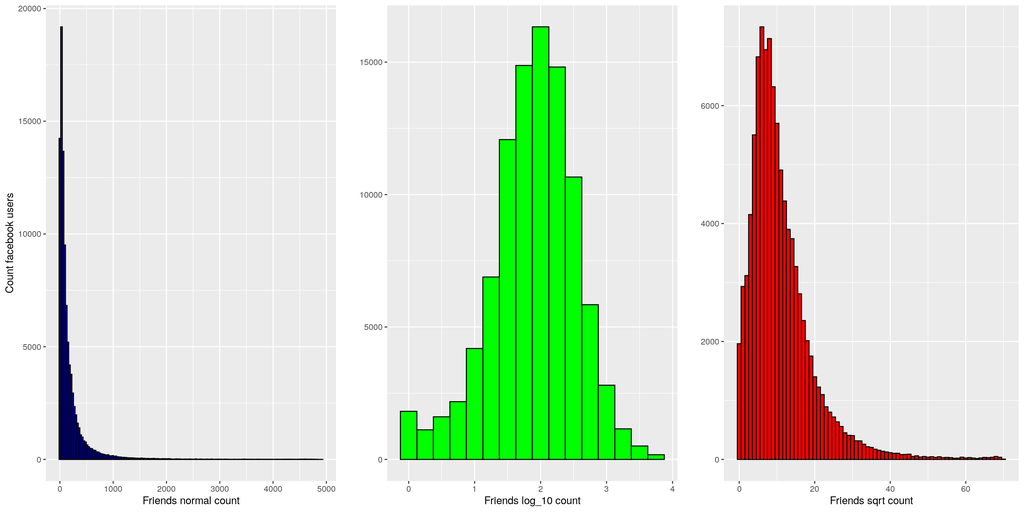

```r
p1 <- ggplot(aes(x = friend_count), data = df) +
  geom_histogram(binwidth = 30, color = 'black', fill = 'blue') +
  ylab('Count facebook users') +
  xlab('Friends normal count')

# Log_10
p2 <- ggplot(aes(x = log10(friend_count)), data = df) +
  geom_histogram(binwidth = .25, color = 'black', fill = 'green') +
  ylab('') +
  xlab('Friends log_10 count')

# SQRT
p3 <- ggplot(aes(x = sqrt(friend_count)), data = df) +
  geom_histogram(binwidth = 1, color = 'black', fill = 'red') +
  ylab('') +
  xlab('Friends sqrt count')

grid.arrange(p1, p2, p3, ncol = 3)
```

### Add a Scaling Layer

Notes:

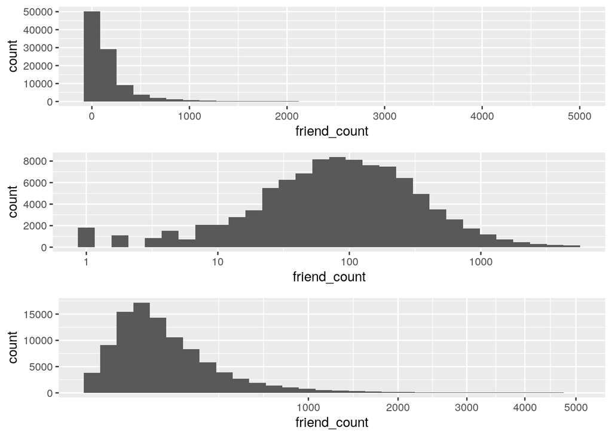

```r
p1 <- ggplot(aes(x = friend_count), data = df) + geom_histogram()
p2 <- p1 + scale_x_log10()
p3 <- p1 + scale_x_sqrt()
grid.arrange(p1, p2, p3, ncol=1)
```

### Frequency Polygons

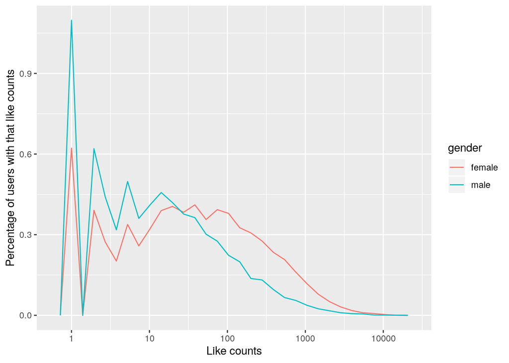

```r
ggplot(aes(x = www_likes, y = ..density..), data = subset(df, !is.na(gender))) +
  geom_freqpoly(aes(color = gender)) +
  scale_x_continuous() +
  scale_x_log10() +
  xlab('Like counts') +
  ylab('Percentage of users with that like counts')
```

### Likes on the Web

Notes:

```r
by(df$www_likes, df$gender, sum)
```

```
## df$gender: female
## [1] 3507665
## --------------------------------------------------------
## df$gender: male
## [1] 1430175
```

### Box Plots

Notes:

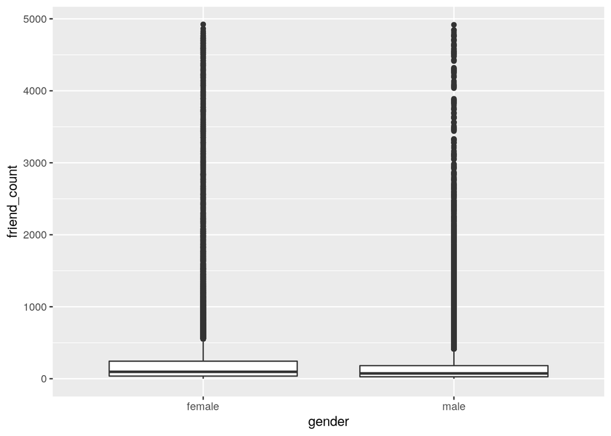

```r
ggplot(aes(x = gender, y = friend_count),
       data = subset(df, !is.na(gender))) +
  geom_boxplot() +
  coord_cartesian()
```

#### Adjust the code to focus on users who have friend counts between 0 and 1000.

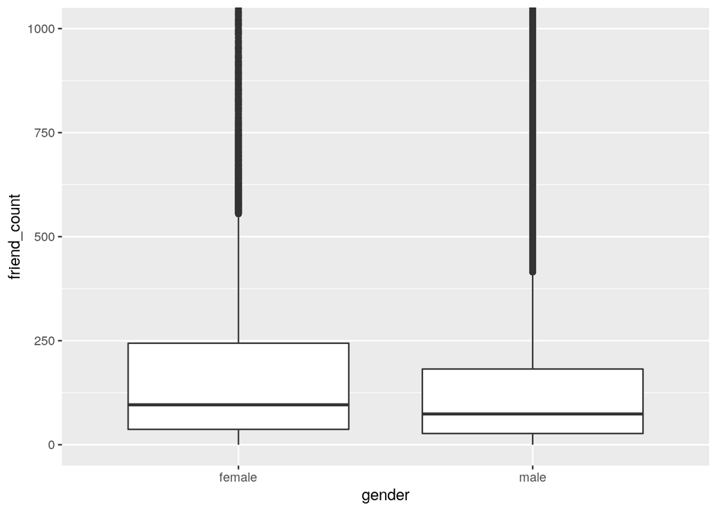

```r
ggplot(aes(x = gender, y = friend_count),
       data = subset(df, !is.na(gender))) +
  geom_boxplot() +
  coord_cartesian(ylim = c(0, 1000))
```

### Box Plots, Quartiles, and Friendships

Notes:

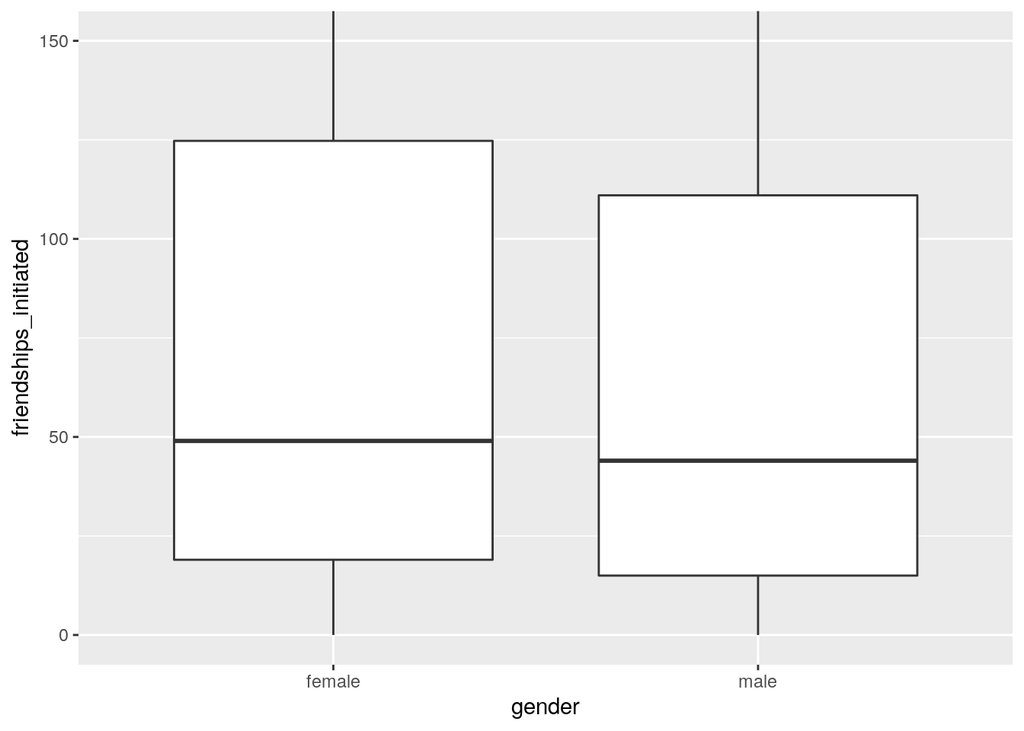

```r
ggplot(aes(x = gender, y = friendships_initiated),
       data = subset(df, !is.na(gender))) +
  geom_boxplot() +
  coord_cartesian(ylim = c(0, 150))
```

#### On average, who initiated more friendships in our sample: men or women?

```r
by(df$friendships_initiated, df$gender, summary)
```

```
## df$gender: female
##    Min. 1st Qu.  Median    Mean 3rd Qu.    Max.
##     0.0    19.0    49.0   113.9   124.8  3654.0
## --------------------------------------------------------
## df$gender: male
##    Min. 1st Qu.  Median    Mean 3rd Qu.    Max.
##     0.0    15.0    44.0   103.1   111.0  4144.0
```

**Response:** Se olharmos para a mediana ou para o primeiro e terceiro quartil verificamos que mulheres tem um maior número de pedidos.

### Getting Logical

Notes:

```r
summary(df$mobile_likes)
```

```
##    Min. 1st Qu.  Median    Mean 3rd Qu.    Max.
##     0.0     0.0     4.0   106.1    46.0 25111.0
```

```r
summary(df$mobile_likes > 0)
```

```
##    Mode   FALSE    TRUE
## logical   35056   63947
```

```r
df$mobile_check_in <- NA
df$mobile_check_in <- ifelse(df$mobile_likes > 0, 1, 0)
df$mobile_check_in <- factor(df$mobile_check_in)
round(summary(df$mobile_check_in) / length(df$mobile_check_in) * 100)
```

```
##  0  1
## 35 65
```

**Response:** 65%

### Analyzing One Variable

**Reflection:** Aprendi a utilizar várias funcionalidades da linguagem R e a trabalhar com o rstudio, também aprendi a fazer analises usando ggplot, analisando valores de variáveis e dividindo em grupos distintos. Também aprendi a modificar o gráfico de forma que a resposta seja visualmente mais compreensível.

Click **KnitHTML** to see all of your hard work and to have an html page of this lesson, your answers, and your notes!